# Tutoriel sur les méthodes avancées d’analyse de survie en contexte multi-omique: Lasso, boosting et importance des variables

Application aux données du TCGA

Date de publication

8 avril 2026

# Introduction

L’analyse de données omiques en oncologie repose sur des jeux de données de grande dimension, caractérisés par un nombre élevé de variables par rapport au nombre de patients. Dans ce contexte, les méthodes de régression pénalisée et d’apprentissage automatique constituent des outils essentiels pour la sélection de variables, la modélisation pronostique et l’interprétation biologique.

Ce tutoriel propose une introduction pratique à plusieurs approches modernes d’analyse de survie adaptées aux données de haute dimension, incluant les régressions pénalisées (*Lasso*, *Group Lasso* et *Priority Lasso*), le *Cox boosting*, ainsi que les méthodes d’évaluation de l’importance des variables dans un cadre non paraamétrique.

Les méthodes présentées permettent d’identifier des signatures moléculaires pertinentes tout en tenant compte de la structure des données (par exemple, regroupement en pathways).

Les analyses sont illustrées à partir des données du projet TCGA, plus spécifiquement de la cohorte CESC (cancer du col de l’utérus) (Lucchesi et Aredes 2016). Ces données combinent informations cliniques et profils omiques (ADN et ARN), offrant un cadre réaliste pour l’évaluation comparative des différentes approches.

Ce tutoriel vise à fournir des éléments méthodologiques et pratiques pour : - construire des modèles pronostiques en présence de données censurées, - sélectionner des variables pertinentes dans des contextes de grande dimension, - comparer différentes stratégies de pénalisation, - et quantifier l’apport incrémental de variables moléculaires au-delà des facteurs cliniques.

L’ensemble des analyses est reproductible et implémenté à l’aide de packages R dédiés, afin de faciliter leur réutilisation dans des contextes similaires.

# Pré-requis

Avant de commencer, assurez-vous d’avoir installé les packages nécessaires et chargé les fonctions du dépôt.

📦 **Installation des packages**

Les packages requis sont listés dans les scripts du projet. Vous pouvez les installer automatiquement avec :

```r
required_packages <- c(
  # Data manipulation
  "tidyverse","janitor","labelled","here","gtools",
  # Summary tables and plots
  "gt","gtsummary","flextable","ggVennDiagram","egg",
  # Survival analysis
  "survival","survminer",
  "glmnet","grpreg","prioritylasso",
  "CoxBoost",
  "ranger","xgboost",
  "SuperLearner",
  "survML",
)

installed <- rownames(installed.packages())
to_install <- setdiff(required_packages, installed)

if (length(to_install) > 0) {
  install.packages(to_install)
}
```

📁 **Chargement des fonctions du dépôt**

Les fonctions personnalisées sont disponibles dans le dossier `R/`. Chargez-les avec :

```r
r_files <- list.files(here::here("R"), pattern = "\\.R$", full.names = TRUE)
invisible(lapply(r_files, source))
```

✅ **Vérification**

```r
lapply(required_packages, require, character.only = TRUE)
```

# Préparation des données

La cohorte TCGA-CESC comprend des patientes atteintes d’un cancer du col de l’utérus primitif, histologiquement confirmé, disposant d’échantillons tumoraux et normaux appariés de haute qualité, adaptés à un profilage moléculaire complet, ainsi que d’annotations cliniques collectées selon les protocoles standardisés du TCGA (Lucchesi et Aredes 2016; The Cancer Genome Atlas Research Network 2017).

Le portail de données du TCGA (https://portal.gdc.cancer.gov) a été utilisé pour obtenir les données de variations du nombre de copies (CNV), de variations nucléotidiques simples (SNV) et d’expression génique (ARN), ainsi que les informations cliniques correspondantes pour les patientes CESC.

La survie sans progression a été dérivée de l’article de Cheng *et al.* (Cheng et al. 2017). Cette ressource fournit des données de survie standardisées et curées pour l’ensemble des types tumoraux du TCGA, permettant des analyses de temps jusqu’à événement.

Les variants somatiques et les altérations du nombre de copies ont été analysés en fonction de leur impact fonctionnel et de la catégorie de gène (oncogène, gène suppresseur de tumeur [TSG], les deux ou inconnu), telle que définie dans OncoKB (v3.1, février 2021).

Pour les oncogènes, ont été retenues les amplifications focales (≤ 10 Mb) ainsi que les variants activateurs — mutations faux-sens pathogènes ou insertions/délétions en phase (in-frame) rapportées dans COSMIC.

Pour les gènes suppresseurs de tumeur, ont été considérées les délétions homozygotes ainsi que les variants inactivants, incluant les mutations faux-sens pathogènes, les indels en phase et les mutations tronquantes (stop-gain, frameshift, sites d’épissage). L’ensemble de ces altérations a également été retenu pour les gènes annotés comme appartenant aux deux catégories ou comme inconnus.

L’intégration et l’harmonisation des données ont consisté à combiner les informations cliniques, génomiques et transcriptomiques au sein de chaque cohorte afin de constituer un jeu de données d’analyse harmonisé. Cette étape incluait des procédures de contrôle qualité, le mapping des variables et l’alignement des caractéristiques moléculaires. Seuls les patients disposant d’annotations cliniques complètes et de profils moléculaires disponibles ont été inclus dans l’analyse.

L’âge au diagnostic a été dichotomisé à 50 ans et codé en variable binaire (≤ 50 vs > 50 ans). Le stade tumoral a été harmonisé selon la classification de la Fédération Internationale de Gynécologie et d’Obstétrique (FIGO), puis dichotomisé en maladie à stade précoce (FIGO I–II) versus avancé (FIGO III–IV). Le statut vis-à-vis du papillomavirus humain (HPV) a été harmonisé en variable binaire (HPV positif vs HPV négatif), sur la base des annotations moléculaires disponibles. Ces variables cliniques ont ensuite été utilisées comme covariables dans l’ensemble des analyses ultérieures.

L’ensemble des gènes OncoKB altérés identifiés a été cartographié dans 26 voies de signalisation, tandis que 257 gènes sont restés non classés. Une voie était considérée comme altérée dès lors qu’au moins un gène appartenant à cette voie présentait une variation somatique.

L’activité des voies a été estimée à l’aide de la méthode *Gene Set Variation Analysis* (GSVA) (Hänzelmann, Castelo, et Guinney 2013), qui calcule, pour chaque échantillon, des scores d’enrichissement pour des ensembles de gènes prédéfinis à partir des profils d’expression transcriptomique. L’analyse par GSVA est une approche non paramétrique et non supervisée qui transforme les données d’expression génique en métriques au niveau des voies, permettant d’évaluer l’activation relative des voies indépendamment des classes. Cette méthode capture les variations coordonnées d’expression des gènes au sein de voies biologiquement définies, fournissant ainsi un résumé robuste de l’activité moléculaire au niveau fonctionnel.

Nous avons utilisé les 50 ensembles de gènes « Hallmark » de la base de données *Molecular Signatures Database* (MSigDB v7.5.1), qui représentent des processus biologiques et des voies de signalisation bien caractérisés (Liberzon et al. 2011). Pour chaque échantillon, les scores GSVA ont été calculés à l’aide du package R `GSVA` avec les paramètres par défaut, après normalisation des données d’expression RNA-seq.

Les listes des processus biologiques et des voies de signalisation dérivées des données génomiques (ADN) et transcriptomiques (ARN) sont présentées respectivement dans les tables suivantes (Table 1; Table 2).

Table 1: Description of the DNA-based pathways

| **N°** | **Pathway** | **Description** |
| --- | --- | --- |
| 1 | Adhesion/Migration | Genes involved in the cellular adhesion / migration |
| 2 | Apoptose | Genes mediating programmed cell death (apoptosis) |
| 3 | Cell cycle | Genes involved in the regulation of the cell cycle |
| 4 | Cellular metabolism | Genes involved in the cellular metabolism |
| 5 | Chromatin organization | Genes involved in the structuring and modulation of chromatin, influencing DNA accessibility and the regulation of gene expression |
| 6 | Developpement ==> Notch | Genes up-regulated by activation of Notch signaling |
| 7 | DNA repair | Genes involved in DNA repair |
| 8 | Epigenetics | Genes involved in the epigenetic mechanisms |
| 9 | Genome integrity ==> p53 | Genes involved in p53 pathways and networks |
| 10 | Hedgehog signaling pathway | Genes up-regulated by activation of hedgehog signaling |
| 11 | Hippo signaling pathway | Genes up-regulated by activation of Hippo signaling |
| 12 | Immunity | Genes involved in the immune response |
| 13 | JAK-STAT signaling pathway | Genes up-regulated by activation of JAK-STAT pathway |
| 14 | mRNA processing | Genes involved in the maturation of messenger RNA (mRNA) |
| 15 | MAPK | Genes up-regulated by activation of the MAPK pathway |
| 16 | Myc | A subgroup of genes regulated by MYC |
| 17 | Oxydative stress | Genes involved in the oxidative stress |
| 18 | PI3K | Genes up-regulated by activation of the PI3K pathway |
| 19 | Proteins processing | Genes involved in the processing of proteins |
| 20 | Regulation of gene expression | Genes involved in the regulation of gene expression |
| 21 | RTK/RAS | Genes up-regulated by activation of RTK/RAS signaling |
| 22 | Senescence | Genes involved in the cellular senescence process |
| 23 | TGF-beta | Genes up-regulated in response to TGF-beta (TGFB) |
| 24 | Transcription-factor regulator | Genes involved in the regulation of transcription factors |
| 25 | Wnt signaling pathway | Genes up-regulated by activation of WNT signaling |
| 26 | Others | Unclassified genes |

Table 2: Description of the RNA-based pathways

| **N°** | **Pathway** | **Description** | **Process category** |
| --- | --- | --- | --- |
| 1 | APICAL_JUNCTION | Genes encoding components of apical junction complex | Cellular component |
| 2 | APICAL_SURFACE | Genes encoding proteins over-represented on the apical surface of epithelial cells, e.g., important for cell polarity (apical area) | Cellular component |
| 3 | PEROXISOME | Genes encoding components of peroxisome | Cellular component |
| 4 | ADIPOGENESIS | Genes up-regulated during adipocyte differentiation (adipogenesis) | Development |
| 5 | ANGIOGENESIS | Genes up-regulated during formation of blood vessels (angiogenesis) | Development |
| 6 | EPITHELIAL_MESENCHIMAL_TRANSITION | Genes defining epithelial-mesenchymal transition, as in wound healing, fibrosis and metastasis | Development |
| 7 | MYOGENESIS | Genes involved in development of skeletal muscle (myogenesis) | Development |
| 8 | SPERMATOGENESIS | Genes up-regulated during production of male gametes (sperm), as in spermatogenesis | Development |
| 9 | PANCREAS_BETA_CELL | Genes specifically up-regulated in pancreatic beta cells | Development |
| 10 | DNA_REPAIR | Genes involved in DNA repair | DNA damage |
| 11 | UV_RESPONSE_DOWN | Genes down-regulated in response to ultraviolet (UV) radiation | DNA damage |
| 12 | UV_RESPONSE_UP | Genes up-regulated in response to ultraviolet (UV) radiation | DNA damage |
| 13 | ALLOGRAFT_REJECTION | Genes up-regulated during transplant rejection | Immune |
| 14 | COAGULATION | Genes encoding components of blood coagulation system; also up-regulated in platelets | Immune |
| 15 | COMPLEMENT | Genes encoding components of the complement system, which is part of the innate immune system | Immune |
| 16 | INTERFERON_ALPHA_RESPONSE | Genes up-regulated in response to alpha interferon proteins | Immune |
| 17 | INTERFERON_GAMMA_RESPONSE | Genes up-regulated in response to gamma interferon (IFNG) | Immune |
| 18 | IL6_JAK_STAT3_SIGNALING | Genes up-regulated by IL6 via STAT3, e.g., during acute phase response | Immune |
| 19 | INFLAMMATORY_RESPONSE | Genes defining inflammatory response | Immune |
| 20 | BILE_ACID_METABOLISM | Genes involve in metabolism of bile acids and salts | Metabolic |
| 21 | CHOLESTEROL_HOMEOSTASIS | Genes involved in cholesterol homeostasis | Metabolic |
| 22 | FATTY_ACID_METABOLISM | Genes encoding proteins involved in metabolism of fatty acids | Metabolic |
| 23 | GLYCOLYSIS | Genes encoding proteins involved in glycolysis and gluconeogenesis | Metabolic |
| 24 | HEME_METABOLISM | Genes involved in metabolism of heme (a cofactor consisting of iron and porphyrin) and erythroblast differentiation | Metabolic |
| 25 | OXIDATIVE_PHOSPHORYLATION | Genes encoding proteins involved in oxidative phosphorylation | Metabolic |
| 26 | XENOBIOTIC_METABOLISM | Genes encoding proteins involved in processing of drugs and other xenobiotics | Metabolic |
| 27 | APOPTOSIS | Genes mediating programmed cell death (apoptosis) by activation of caspases | Pathway |
| 28 | HYPOXIA | Genes up-regulated in response to low oxygen levels (hypoxia) | Pathway |
| 29 | PROTEIN_SECRETION | Genes involved in protein secretion pathway | Pathway |
| 30 | ULFOLDED_PROTEIN_RESPONSE | Genes up-regulated during unfolded protein response, a cellular stress response related to the endoplasmic reticulum | Pathway |
| 31 | REACTIVE_OXYGEN_SPECIES_PATHWAY | Genes up-regulated by reactive oxigen species (ROS) | Pathway |
| 32 | E2F_TARGETS | Genes encoding cell cycle related targets of E2F transcription factors | Proliferation |
| 33 | G2M_CHECKPOINT | Genes involved in the G2/M checkpoint, as in progression through the cell division cycle | Proliferation |
| 34 | MYC_TARGETS_V1 | A subgroup of genes regulated by MYC - version 1 (v1) | Proliferation |
| 35 | MYC_TARGETS_V2 | A subgroup of genes regulated by MYC - version 2 (v2) | Proliferation |
| 36 | P53_PATHWAY | Genes involved in p53 pathways and networks | Proliferation |
| 37 | MITOTIC_SPINDLE | Genes important for mitotic spindle assembly | Proliferation |
| 38 | ANDROGEN_RESPONSE | Genes defining response to androgens | Signaling |
| 39 | ESTROGEN_RESPONSE_EARLY | Genes defining early response to estrogen | Signaling |
| 40 | ESTROGEN_RESPONSE_LATE | Genes defining late response to estrogen | Signaling |
| 41 | IL2_JAK_STAT5_SIGNALING | Genes up-regulated by STAT5 in response to IL2 stimulation | Signaling |
| 42 | KRAS_SIGNALING_UP | Genes up-regulated by KRAS activation | Signaling |
| 43 | KRAS_SIGNALING_DOWN | Genes down-regulated by KRAS activation | Signaling |
| 44 | MTORC1_SIGNALING | Genes up-regulated through activation of mTORC1 complex | Signaling |
| 45 | NOTCH_SIGNALING | Genes up-regulated by activation of Notch signaling | Signaling |
| 46 | PI3K_AKT_MTOR_SIGNALING | Genes up-regulated by activation of the PI3K/AKT/mTOR pathway | Signaling |
| 47 | HEDGEHOG_SIGNALING | Genes up-regulated by activation of hedgehog signaling | Signaling |
| 48 | TGF_BETA_SIGNALING | Genes up-regulated in response to TGF-beta 1 (TGFB1) | Signaling |
| 49 | TNFA_SIGNALING_VIA_NFKB | Genes regulated by NF-kB in response to TNF | Signaling |
| 50 | WNT_BETA_CATENIN_SIGNALING | Genes up-regulated by activation of WNT signaling through accumulation of beta catenin CTNNB1 | Signaling |

Les données prétraitées peuvent être importées directement à l’aide de la fonction `read_processed()`.

```r
tcga <- read_processed(cohort = "tcga")
tcga_clin <- tcga$clin
tcga_pathway <- tcga$pathway$clin_dna_rna
```

# Analyse descriptive

Des diagrammes de Venn illustrant la répartition des patients en fonction de la disponibilité des données de séquençage ou des données omiques et des données cliniques sont présentés respectivement dans Figure 1 et Figure 2. Au total, 228 patients ont été inclus dans l’analyse.

Figure 1: Venn diagram of patient distribution by sequencing and clinical data

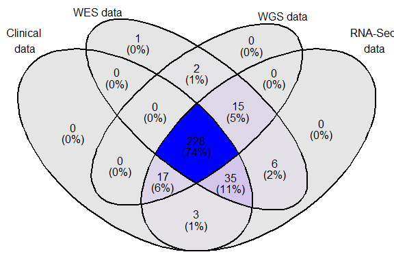

```r
plot_venn_diagram_samples(tcga_clin, type = "sequencing")
```

Figure 2: Venn diagram of patient distribution by omics and clinical data

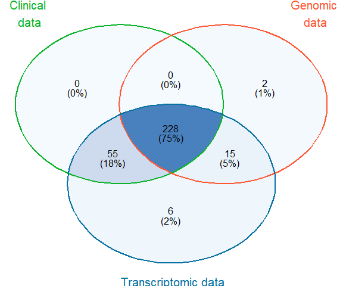

```r
plot_venn_diagram_samples(tcga_clin, type = "omics")
```

```r
tcga_pathway %>%
  dplyr::select(starts_with("genomic_pathway"))%>%
  tbl_summary(digits = everything()~c(0,0))%>%
  modify_header(label = "")%>%
  bold_labels()%>%
  as_gt()%>%
  tab_options(quarto.disable_processing = TRUE)
```

Table 3: Pathway-level frequencies of DNA alterations

|  | **N = 228**<sup>1</sup> |
| --- | --- |
| Adhesion/Migration | 37 (16%) |
| Apoptosis | 31 (14%) |
| Cell cycle | 36 (16%) |
| Cellular Metabolism | 23 (10%) |
| Chromatin organization | 23 (10%) |
| Development ==> Notch | 61 (27%) |
| DNA repair | 75 (33%) |
| Epigenetics | 100 (44%) |
| Genome integrity ==> p53 | 24 (11%) |
| Hedgehog signaling pathway | 4 (2%) |
| Hippo signaling pathway | 60 (26%) |
| Immunity | 52 (23%) |
| JAK-STAT signaling pathway | 18 (8%) |
| MAPK | 33 (14%) |
| mRNA Processing | 7 (3%) |
| Myc | 12 (5%) |
| Oxydative stress | 13 (6%) |
| PI3K | 105 (46%) |
| Proteins Processing | 4 (2%) |
| Regulation Of Gene Expression | 54 (24%) |
| RTK/RAS | 103 (45%) |
| Senescence | 3 (1%) |
| TGF-beta | 25 (11%) |
| Transcription factor-regulator | 73 (32%) |
| Wnt Signaling Pathway | 53 (23%) |
| Others | 158 (69%) |

<sup>1</sup> n (%)

Figure 3: Pathway-level frequencies of DNA alterations

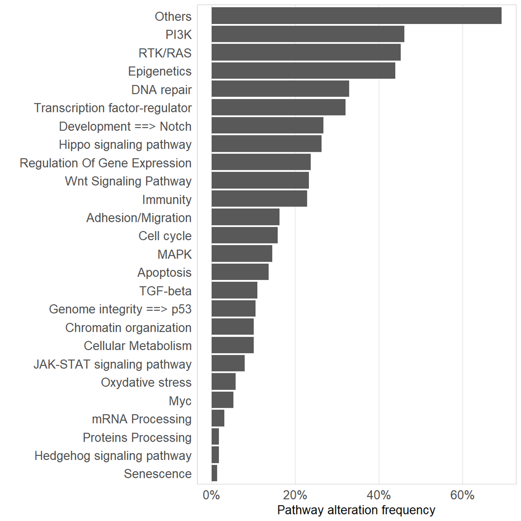

```r
plot_dichotomous(tcga_pathway,
                 var_prefix = "genomic_pathway_",
                 with_group = FALSE,
                 xlab = "",
                 ylab = "Pathway alteration frequency",
                 process_panel = F)
```

```r
tcga_pathway %>%
  dplyr::select(starts_with("hallmark_"))%>%
  tbl_summary(digits = everything()~c(2,2))%>%
  modify_header(label = "")%>%
  bold_labels()%>%
  as_gt()%>%
  tab_options(quarto.disable_processing = TRUE)
```

Table 4: Distribution of RNA-based pathway activity scores

|  | **N = 228**<sup>1</sup> |
| --- | --- |
| HALLMARK_ADIPOGENESIS | -0.01 (-0.13, 0.09) |
| HALLMARK_ALLOGRAFT_REJECTION | 0.00 (-0.31, 0.32) |
| HALLMARK_ANDROGEN_RESPONSE | -0.03 (-0.15, 0.14) |
| HALLMARK_ANGIOGENESIS | -0.01 (-0.26, 0.30) |
| HALLMARK_APICAL_JUNCTION | -0.01 (-0.17, 0.15) |
| HALLMARK_APICAL_SURFACE | 0.00 (-0.14, 0.16) |
| HALLMARK_APOPTOSIS | -0.01 (-0.17, 0.16) |
| HALLMARK_BILE_ACID_METABOLISM | -0.03 (-0.13, 0.10) |
| HALLMARK_CHOLESTEROL_HOMEOSTASIS | 0.00 (-0.18, 0.13) |
| HALLMARK_COAGULATION | -0.01 (-0.20, 0.23) |
| HALLMARK_COMPLEMENT | 0.02 (-0.22, 0.23) |
| HALLMARK_DNA_REPAIR | -0.03 (-0.16, 0.11) |
| HALLMARK_E2F_TARGETS | 0.03 (-0.28, 0.25) |
| HALLMARK_EPITHELIAL_MESENCHYMAL_TRANSITION | -0.04 (-0.31, 0.29) |
| HALLMARK_ESTROGEN_RESPONSE_EARLY | 0.00 (-0.12, 0.10) |
| HALLMARK_ESTROGEN_RESPONSE_LATE | 0.00 (-0.10, 0.09) |
| HALLMARK_FATTY_ACID_METABOLISM | -0.03 (-0.14, 0.11) |
| HALLMARK_G2M_CHECKPOINT | 0.00 (-0.27, 0.23) |
| HALLMARK_GLYCOLYSIS | -0.03 (-0.16, 0.11) |
| HALLMARK_HEDGEHOG_SIGNALING | -0.01 (-0.17, 0.20) |
| HALLMARK_HEME_METABOLISM | 0.00 (-0.10, 0.09) |
| HALLMARK_HYPOXIA | -0.02 (-0.19, 0.15) |
| HALLMARK_IL2_STAT5_SIGNALING | -0.01 (-0.18, 0.17) |
| HALLMARK_IL6_JAK_STAT3_SIGNALING | 0.01 (-0.30, 0.27) |
| HALLMARK_INFLAMMATORY_RESPONSE | 0.03 (-0.27, 0.27) |
| HALLMARK_INTERFERON_ALPHA_RESPONSE | -0.06 (-0.40, 0.43) |
| HALLMARK_INTERFERON_GAMMA_RESPONSE | -0.02 (-0.35, 0.36) |
| HALLMARK_KRAS_SIGNALING_DN | 0.02 (-0.08, 0.13) |
| HALLMARK_KRAS_SIGNALING_UP | 0.01 (-0.18, 0.19) |
| HALLMARK_MITOTIC_SPINDLE | 0.00 (-0.18, 0.17) |
| HALLMARK_MTORC1_SIGNALING | -0.02 (-0.21, 0.17) |
| HALLMARK_MYC_TARGETS_V1 | -0.02 (-0.31, 0.26) |
| HALLMARK_MYC_TARGETS_V2 | -0.05 (-0.37, 0.31) |
| HALLMARK_MYOGENESIS | -0.02 (-0.14, 0.12) |
| HALLMARK_NOTCH_SIGNALING | -0.02 (-0.14, 0.13) |
| HALLMARK_OXIDATIVE_PHOSPHORYLATION | -0.03 (-0.30, 0.25) |
| HALLMARK_P53_PATHWAY | 0.01 (-0.17, 0.17) |
| HALLMARK_PANCREAS_BETA_CELLS | 0.09 (-0.11, 0.23) |
| HALLMARK_PEROXISOME | 0.00 (-0.11, 0.11) |
| HALLMARK_PI3K_AKT_MTOR_SIGNALING | -0.02 (-0.15, 0.13) |
| HALLMARK_PROTEIN_SECRETION | -0.02 (-0.20, 0.19) |
| HALLMARK_REACTIVE_OXYGEN_SPECIES_PATHWAY | -0.03 (-0.22, 0.15) |
| HALLMARK_SPERMATOGENESIS | -0.03 (-0.16, 0.15) |
| HALLMARK_TGF_BETA_SIGNALING | -0.01 (-0.23, 0.20) |
| HALLMARK_TNFA_SIGNALING_VIA_NFKB | -0.06 (-0.31, 0.31) |
| HALLMARK_UNFOLDED_PROTEIN_RESPONSE | -0.02 (-0.18, 0.13) |
| HALLMARK_UV_RESPONSE_DN | 0.00 (-0.17, 0.19) |
| HALLMARK_UV_RESPONSE_UP | -0.01 (-0.13, 0.14) |
| HALLMARK_WNT_BETA_CATENIN_SIGNALING | -0.02 (-0.16, 0.11) |
| HALLMARK_XENOBIOTIC_METABOLISM | -0.02 (-0.13, 0.11) |

<sup>1</sup> Median (Q1, Q3)

Figure 4: Distribution of RNA-based pathway activity scores

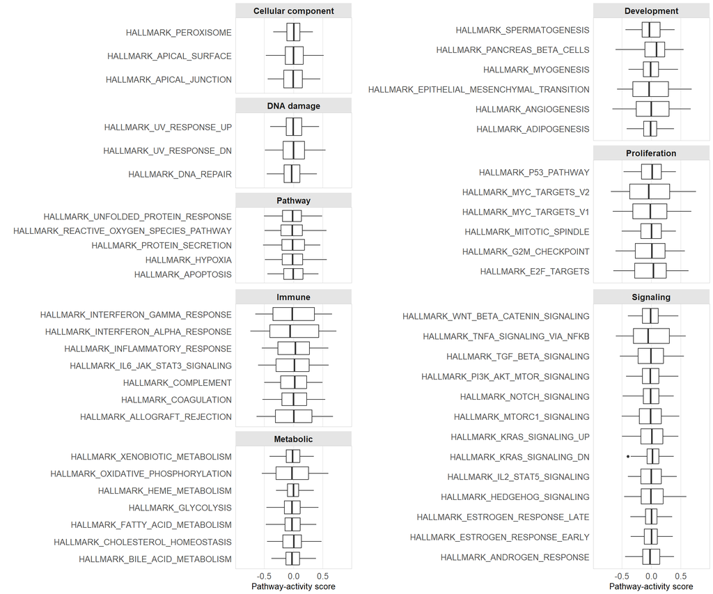

```r
plot_continuous(tcga_pathway,
                var_prefix = "hallmark_",
                with_group = FALSE,
                xlab = "",
                ylab = "Pathway-activity score",
                process_panel = T)
```

Survie sans progression

Figure 5: Progression-free survival (PFS) curve

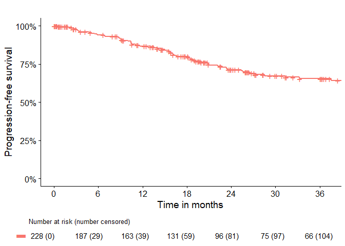

```r
plot_surv(formula      = list(Surv(time, event) ~ 1),
          data         = tcga_pathway)
```

```r
survfit(Surv(time, event) ~ 1, data = tcga_pathway)%>%
  tbl_survfit(times        = c(12,24,36),
              label_header = "**{time} months-PFS rate (95% CI)**",
              statistic    = "{estimate} [{conf.low}-{conf.high}]")%>%
  modify_header(label = "")%>%
  as_gt()%>%
  tab_options(quarto.disable_processing = TRUE)
```

Table 5: Progressiion-free survival rates

|  | **12 months-PFS rate (95% CI)** | **24 months-PFS rate (95% CI)** | **36 months-PFS rate (95% CI)** |
| --- | --- | --- | --- |
| Overall | 87% [82%-92%] | 71% [65%-78%] | 65% [58%-73%] |

# Régression de Cox

Le modèle de Cox (Cox 1972) exprime la fonction de risque instantané d’événement $\lambda$ en fonction du temps $t$ et des covariables $X_{1}, \cdots, X_{n}$ :

$${\displaystyle \lambda \left(t,X_{1},\cdots ,X_{n}\right)=\lambda _{0}\left(t\right)\exp \left(\Sigma _{i=1}^{n}\beta _{i}X_{i}\right)}$$
Pour un individu, la fonction ${\displaystyle \lambda \left(t,X_{1},\cdots ,X_{n}\right)}$ correspond au risque instantané d’événement à l’instant $t$ sachant qu’il n’a pas encore subi l’événement juste avant $t$. ${\displaystyle \lambda _{0}\left(t\right)}$ correspond au risque instantané d’événement lorsque toutes les covariables sont nulles. Il s’agit du risque de base.

Le modèle de Cox est dit *semi-paramétrique*. On ne cherche pas à estimer la fonction $\lambda_{0}(t)$ qui est la même pour tous les individus à un instant donné. On s’intéresse au rapport des risques instantanés d’événement pour deux individus exposés à des facteurs de risque différents. Il en découle de cette formule l’hypothèse des risques proportionnels. Soit deux individus $j_{1}$ et $j_{2}$ qui ne diffèrent que par une seule covariable, disons la $k$-ième. On peut imaginer que cette covariable vaut 0 chez $j_{1}$ et 1 chez $j_{2}$. On obtient alors, quel que soit $t$ :

$${\frac {\lambda \left(t,j_{2}\right)}{\lambda \left(t,j_{1}\right)}}={\frac {\lambda _{0}\left(t\right)\exp \left(\beta _{1}X_{1}^{'}+\cdots +\beta _{k-1}X_{k-1}^{'}+\beta _{k}\times 1+\beta _{k+1}X_{k+1}^{'}+\cdots +\beta _{n}X_{n}^{'}\right)}{\lambda _{0}\left(t\right)\exp \left(\beta _{1}X_{1}^{'}+\cdots +\beta _{k-1}X_{k-1}^{'}+\beta _{k}\times 0+\beta _{k+1}X_{k+1}^{'}+\cdots +\beta _{n}X_{n}^{'}\right)}}=\exp \left(\beta _{k}\right)$$

Le rapport est donc indépendant du temps, autrement dit, quel que soit le temps $t$, l’individu $j_{2}$ a un risque instantané d’événement $\exp(\beta _{k})$ fois celui de l’individu $j_{1}$.

L’estimation des coefficients $\beta_{k}|k=1\cdots n$ se fait par la méthode du maximum de vraisemblance proposée par Breslow. La vraisemblance d’un échantillon est en fait la probabilité d’observer cet échantillon, intuitivement donc, on veut maximiser cette probabilité.

Soit :

- $X_{i}$ le vecteur colonne des covariables de la *i*-ème personne
- $\beta$ le vecteur colonne des coefficients $\beta_{i}$
- $t_{i}|i=1\cdots m$ les temps d’événements
- $d_{i}$ le nombre d’événements au temps $t_{i}$
- $D_{i}$ l’ensemble des événements au temps $t_{i}$
- $r_{i}$ le nombre d’individus à risque d’événement au temps $t_{i}^{-}$
- $R_{i}$ l’ensemble des individus à risque d’événement au temps $t_{i}^{-}$

Au temps $t_{i}$, la probabilité qu’un sujet $k$ subisse l’événement sachant qu’il n’a pas présenté l’événement au temps $t_{i}^{-}$ est :
$$\lambda _{0}\left(t_{i}\right)\exp \left(X_{k}^{\operatorname {t} }\beta \right)dt$$
Au temps $t_{i}$, la vraisemblance de l’ensemble des individus appartenant à $D_{i}$ s’écrit alors :

$${\frac {\exp \left(\beta ^{\operatorname {t} }\Sigma _{k\in D_{i}}X_{k}\right)}{\left[\Sigma _{l\in R_{i}}\exp \left(\beta ^{\operatorname {t} }X_{l}\right)\right]^{d_{i}}}}$$

La fonction de vraisemblance (partielle) de Cox s’écrit alors :
$$L\left(\beta \right)=\prod _{i=1}^{m}{\frac {\exp \left(\beta ^{\operatorname {t} }\Sigma _{k\in D_{i}}X_{k}\right)}{\left[\Sigma _{l\in R_{i}}\exp \left(\beta ^{\operatorname {t} }X_{l}\right)\right]^{d_{i}}}}$$

Il s’agit donc de résoudre l’équation de sorte que $L\left(\beta \right)$ soit maximale. La valeur $V$ pour laquelle la fonction $L$ atteint son maximum est la vraisemblance de l’échantillon. On parle de vraisemblance partielle car seuls les sujets subissant l’événement d’intérêt entrent dans l’estimation de la fonction de vraisemblance, les sujets censurés n’étant considérés qu’indirectement. La vraisemblance partielle de Cox est indépendante du risque de base $\lambda_{0}(t)$ et donc de ses paramètres qui ne peuvent alors pas être estimés par cette approche.

Pour faciliter l’optimisation et le calcul numérique, la log-vraisemblance partielle $l$ (et non la vraisemblance partielle $L$) est utilisée pour estimer les coefficients $\beta$ :

$$\widehat{\beta} = \underset{\beta}{\mathrm{argmax}} (l(\beta)),$$
avec $l(\beta)=log(L(\beta))$ la log-vraisemblance partielle.

Table 6: Régression de Cox

```r
tbl_cox_univ <- tbl_cox(
  data   = tcga_pathway,
  time   = "time",
  event  = "event",
  covars = c("age_c_f", "figo_c_f", "hpv_negative_f"),
  model  = "univ"
)

tbl_cox_multi <- tbl_cox(
  data   = tcga_pathway,
  time   = "time",
  event  = "event",
  strata = "cohort",
  covars = c("age_c_f", "figo_c_f", "hpv_negative_f"),
  model  = "multi"
)

list(tbl_cox_univ, tbl_cox_multi)%>%
  tbl_merge(tab_spanner = c("**Univariate Cox regression**",
                            "**Multivariate Cox regression**"))%>%
  modify_column_hide(columns = c(stat_n_1_2, stat_nevent_1_2))%>%
  modify_spanning_header(c(stat_n_1, stat_nevent_1)~NA)%>%
  as_gt()
```

[output not shown]

# Régression pénalisée de Cox

## *Lasso*

Le programme d’optimisation à résoudre pour la méthode Lasso proposée par Tibshirani (Tibshirani 1997) prend la forme suivante :

$$\widehat{\beta}^{\text{Lasso}}(\lambda)
= \underset{\beta}{\arg\min} \left( l(\beta) + \lambda \|\beta\|_{1} \right),
\quad \lambda \geq 0$$
où $l(\beta)$ représente la log-vraisemblance partielle de Cox, $\lambda$ représente le paramètre de régularisation contrôlant l’importance de la pénalisation. La norme $\ell1$, utilisée dans la pénalisation Lasso permet d’assigner des coefficients $\beta$ à 0.

Le paramètre $\lambda$ permettant d’estimer les coefficiens $\beta$ pondère l’influence de la pénalité. Plus $\lambda$ est élevé, plus l’on accorde de l’importance de la pénalisation, et plus les coefficients $\beta$ seront réduits à 0. A l’inverse, si $\lambda=0$, aucune pénalité ne sera appliquée.

Le paramètre $\lambda$ peut être fixé par validation croisée à 5 blocs par la procédure suivante :

1. Partitionner l’ensemble d’apprentissage en 5 sous-ensembles.
2. Estimer le vecteur des coefficients $\beta$ en maximisant la vraisemblance partielle avec pénalisation sur 4 sous-ensembles
3. Calculer une déviance à partir de la log-vraisemblance partielle totale $l$ en utilisant les 5 sous-ensembles et de la log-vraisemblance partielle $l_{-i}$ calculée à partir des 4 sous-ensembles utilisées précédemment :

$$\hat{CV}_{i}(\lambda)=l(\beta_{-i}(\lambda))-l_{-i}(\beta_{-i}(\lambda))$$
4. Recommencer ce procédé à partir de l’étape 3, en enlevant un autre sous-ensemble $i$ et en gardant la même valeur de $\lambda$.

On obtient alors 5 valeurs pour $\widehat{CV}_{i}(\lambda)$, ce qui nous permet de calculer une déviance moyenne (ou erreur moyenne) pour le $\lambda$ considéré :

$$\hat{CV}(\lambda)=\frac{1}{5} \sum_{i=1}^{5} \hat{CV}_{i}(\lambda)$$

Cette procédure est répétée pour différentes valeurs de $\lambda$¸ en gardant le même partitionnement des patients. Deux heuristiques classiques sont utilisées pour fixer le poids de la pénalisation $\lambda$ :

1. Choisir le paramètre $\lambda$ qui minimise l’erreur moyenne, $\lambda_{min}$
2. Choisir le plus grand $\lambda$¸ tel que l’erreur moyenne est inférieure à un écart-type de l’erreur moyenne minimale, $\lambda_{1se}$. Cette méthode permet de fixer une valeur de $\lambda$ plus importante et d’assigner plus de poids à la pénalité. Ainsi, moins de variables seront sélectionnées, et le modèle sera plus parcimonieux.

```r
time <- tcga_pathway$time
event <- tcga_pathway$event
clin <- c("age","figo","hpv_negative")
dna_pattern <- "altered_|genomic_pathway_"
rna_pattern <- "rna_seq_|hallmark_"
X_names <- tcga_pathway %>%
  dplyr::select(all_of(clin),
                tidyselect::matches(dna_pattern),
                tidyselect::matches(rna_pattern))%>%
  colnames()
X <- tcga_pathway %>% dplyr::select(all_of(X_names))

cox_lasso_fit <- fit_cox_lasso(
  time  = time,
  event = event,
  X     = X,
  seed  = 123
)
```

```r
cox_lasso_fit$fit$cv.glmnet
```

```
Call:  glmnet::cv.glmnet(x = X, y = Y, nfolds = nfolds, family = "cox",      alpha = 1)

Measure: Partial Likelihood Deviance

     Lambda Index Measure     SE Nonzero
min 0.03762    14   10.83 0.3834      20
1se 0.10469     3   11.18 0.2508       3
```

Figure 6: Cross-validation results for standard Lasso regression

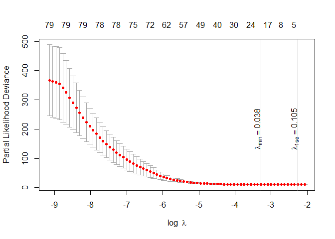

```r
mod = cox_lasso_fit$fit$cv.glmnet$glmnet.fit
lambda_optimal <- cox_lasso_fit$fit$cv.glmnet$lambda.min
lambda_1se <- cox_lasso_fit$fit$cv.glmnet$lambda.1se

plot(cox_lasso_fit$fit$cv.glmnet, xlab = expression(log~~lambda))
abline(v = log(lambda_optimal), col = "gray")
text(log(lambda_optimal)-0.1, 200, bquote(paste(lambda["min"]==.(round(lambda_optimal, 3)))), srt = 90)
abline(v = log(cox_lasso_fit$fit$cv.glmnet$lambda.1se), col = "gray")
text(log(lambda_1se)-0.1, 200, bquote(paste(lambda["1se"]==.(round(lambda_1se, 3)))), srt = 90)
```

Figure 7: Coefficient paths for the Lasso Cox model

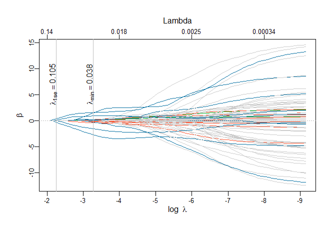

```r
betas <- as.vector(coef(mod, s = lambda_optimal))
beta.clin <- X_names[betas!=0 & X_names %in% clin]
beta.dna <- X_names[betas!=0 & stringr::str_starts(X_names, dna_pattern)]
beta.rna <- X_names[betas!=0 & stringr::str_starts(X_names, rna_pattern)]

# get ordered list of variables as they appear at smallest lambda
allnames <- names(coef(mod)[, ncol(coef(mod))]
                  [order(coef(mod)[, ncol(coef(mod))], decreasing = TRUE)])
# assign colors
cols <- rep("gray80", length(allnames))
cols[allnames %in% beta.clin] <- "#0AB329"
cols[allnames %in% beta.dna] <- "#FF5733"
cols[allnames %in% beta.rna] <- "#0771A2"

# draw coefficient paths of a Lasso Cox model
plotmo::plot_glmnet(mod,
                    label = FALSE, col = cols,
                    xlab = expression(log ~ ~lambda),
                    ylab = expression(beta),
                    lwd = 1.5
)
abline(v = log(lambda_optimal), col = "gray")
text(log(lambda_optimal)+0.1, 7, bquote(paste(lambda["min"]==.(round(lambda_optimal, 3)))), srt = 90)
abline(v = log(cox_lasso_fit$fit$cv.glmnet$lambda.1se), col = "gray")
text(log(lambda_1se)+0.1, 7, bquote(paste(lambda["1se"]==.(round(lambda_1se, 3)))), srt = 90)
```

Figure 8: Coefficient values of selected variables in the Lasso Cox model

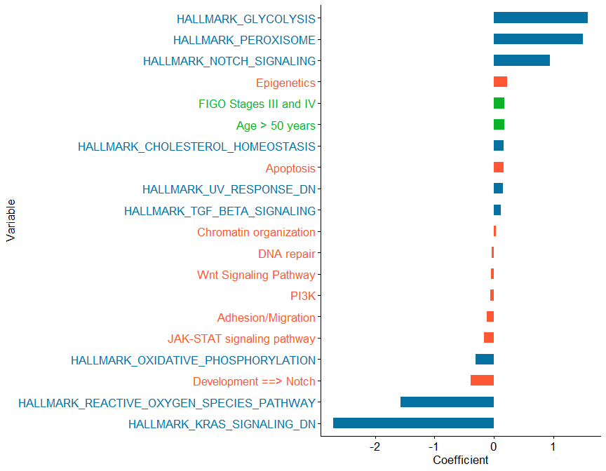

```r
plot_coef(cox_lasso_fit, data_type = T)
```

## *Group Lasso*

La méthode *Lasso* permettant de sélectionner des variables de manière individuelle a été étendue pour la sélection d’un ensemble de variables contenues dans des groupes définis *a priori* (Breheny et Huang 2009, 2015). La méthode *Group Lasso* utilise une pénalité sur le groupe permettant la sélection d’un ou de plusieurs groupes en entier.

Supposons que $X = X_{1}, \cdots, X_{G}$ est divisé en $G$ groupes de variables. $X_{G}$ contient $p_{g}$ variables et $\beta_{g}=\beta_{1},\cdots, \beta_{G}$ représentent les coefficients de régression associés à $X = X_{1}, \cdots, X_{G}$. Le problème d’optimisation à résoudre est le suivant :

$$\widehat{\beta}^{\text{GLasso}}(\lambda)
= \underset{\beta}{\mathrm{argmin}}
\left(
l(\beta) + \lambda \sum_{g=1}^{G} \|\beta_g\|_2
\right),
\quad \lambda \ge 0$$

```r
group <- as.factor(
  dplyr::case_when(
    X_names %in% clin ~ "Clinical",
    stringr::str_starts(X_names, dna_pattern) ~ "DNA",
    stringr::str_starts(X_names, rna_pattern)  ~ "RNA",
    TRUE ~ NA_character_
  )
)
table(group)
```

```
group
Clinical      DNA      RNA
       3       26       50
```

```r
cox_group_lasso_fit <- fit_cox_group_lasso(
  time  = time,
  event = event,
  X     = X,
  group = group,
  seed  = 123
)

summary(cox_group_lasso_fit$fit$cv.grpsurv)
```

```
grLasso-penalized Cox regression with n=228, p=79
At minimum cross-validation error (lambda=0.0316):
-------------------------------------------------
  Nonzero coefficients: 79
  Nonzero groups: 3
  Cross-validation error of 9.38
  Maximum R-squared: 0.14
  Maximum signal-to-noise ratio: 0.02
```

L’erreur d’apprentissage est minimale ($min[MSE]=$ 9.38) lorsque $\lambda=$ 0.0316. Les 3 groupes (cliniques, DNA et RNA) ont été sélectionnées.

Figure 9: Cross-validation results for Group Lasso regression

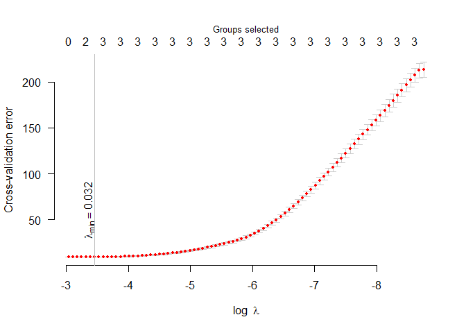

```r
lambda_optimal <- cox_group_lasso_fit$fit$cv.grpsurv$lambda.min
plot(cox_group_lasso_fit$fit$cv.grpsurv, xlab = expression(log~~lambda))
abline(v = log(lambda_optimal), col = "gray")
text(log(lambda_optimal)+0.1, 60, bquote(paste(lambda["min"]==.(round(lambda_optimal, 3)))), srt = 90)
```

Figure 10: Coefficient paths for the Group Lasso Cox model

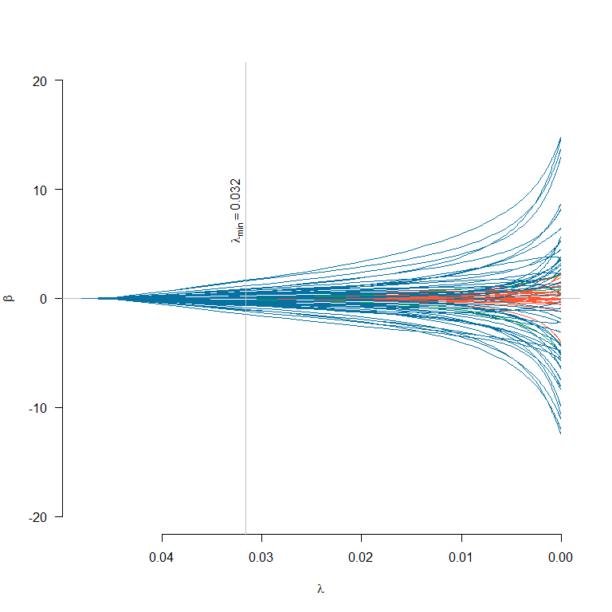

```r
lambda_optimal <- cox_group_lasso_fit$fit$cv.grpsurv$lambda.min
plot(cox_group_lasso_fit$fit$grpsurv, ylab = expression(beta),
     ylim = c(-20,20), col = c("#0AB329","#FF5733","#0771A2"))
abline(v = lambda_optimal, col = "gray")
text(lambda_optimal+0.001, 8, bquote(paste(lambda["min"]==.(round(lambda_optimal, 3)))), srt = 90)
```

Figure 11: Coefficient values of selected variables in the Group Lasso Cox model

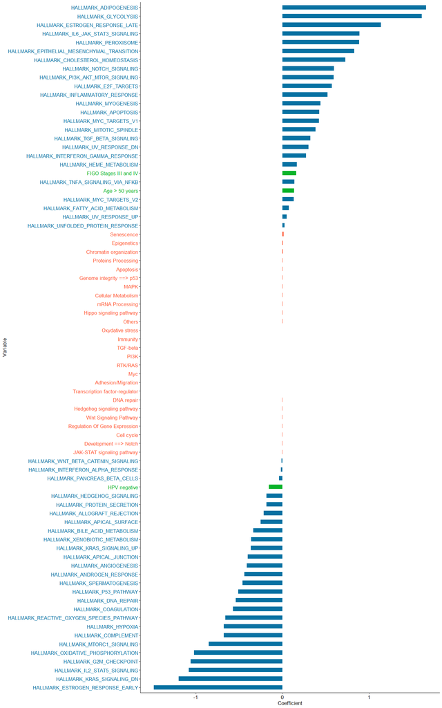

```r
plot_coef(cox_group_lasso_fit, data_type = T)
```

## *Priority Lasso*

La régression de Cox utilisant le *priority-Lasso* permet l’ajustement de modèles Lasso successifs pour plusieurs blocs ordonnés de données (Klau et al. 2018).

Les observations $p_{m}$ du bloc $m$ pour le sujet $i$ sont désignées par $x^{(m)}_{i1},\cdots,x^{m}_{ip_{m}}$ pour $i=1,\cdots,n$ et $m=1,\cdots,M$. $\beta^{(m)}_{j}$ représentent les coefficients de régression de la $j$ème variable du bloc $m$ avec $j=1,\cdots, p_{m}$ tandis que $\hat{\beta}^{(m)}_{j}$ représente les coefficients de régression estimés. Soit $\pi_{1},\cdots, \pi_{M}$ les indices définissant l’ordre de priorité des blocs $M$ : $\pi_{1}$ désigne l’indice du bloc ayant la priorité la plus élevée tandis que $\pi_{M}$ est l’indice du bloc ayant la priorité la plus faible.

Dans la première étape de la méthode *Priority-Lasso*, les variables du bloc $\pi_{1}$ sont utilisées pour ajuster le modèle de Cox avec pénalisation Lasso. Les coefficients $\beta^{(\pi_{1})}_{1},\cdots,\beta^{(\pi_{1})}_{p_{\pi_{1}}}$ sont estimés en minimisant

$$\sum_{i=1}^n\left(y_i-\sum_{j=1}^{p_{\pi_1}} x_{i j}^{\left(\pi_1\right)} \beta_j^{\left(\pi_1\right)}\right)^2+\lambda^{\left(\pi_1\right)} \sum_{j=1}^{p_{\pi_1}}\left|\beta_j^{\left(\pi_1\right)}\right| .$$

Le prédicteur linéaire ajusté à l’étape 1 est

$$\hat{\eta}_{1, i}(\pi)=\hat{\beta}_1^{\left(\pi_1\right)} x_{i 1}^{\left(\pi_1\right)}+\ldots+\hat{\beta}_{p_{\pi_1}}^{\left(\pi_1\right)} x_{i p_{\pi_1}}^{\left(\pi_1\right)}.$$

Ce prédicteur linéaire est utilisée comme *offset* dans l’étape suivante au cours de laquelle un nouveau modèle de Cox avec pénalisation Lasso est ajusté pour le bloc $\pi_{2}$.

Dans un premier temps, nous définissons les blocs ainsi que leur ordre de priorité.

```r
index_clin = which(X_names %in% clin)
index_dna  = which(stringr::str_starts(X_names, dna_pattern))
index_rna  = which(stringr::str_starts(X_names, rna_pattern))
lapply(list(index_clin, index_dna, index_rna), head)
```

```
[[1]]
[1] 1 2 3

[[2]]
[1] 4 5 6 7 8 9

[[3]]
[1] 30 31 32 33 34 35
```

```r
blocks_list <- do.call(.make_blocks_priority_lasso,
                       unname(purrr::compact(list(index_clin,
                                                  index_dna,
                                                  index_rna))))
str(blocks_list)
```

```
List of 6
 $ :List of 3
  ..$ bp1: int [1:3] 1 2 3
  ..$ bp2: int [1:26] 4 5 6 7 8 9 10 11 12 13 ...
  ..$ bp3: int [1:50] 30 31 32 33 34 35 36 37 38 39 ...
 $ :List of 3
  ..$ bp1: int [1:3] 1 2 3
  ..$ bp2: int [1:50] 30 31 32 33 34 35 36 37 38 39 ...
  ..$ bp3: int [1:26] 4 5 6 7 8 9 10 11 12 13 ...
 $ :List of 3
  ..$ bp1: int [1:26] 4 5 6 7 8 9 10 11 12 13 ...
  ..$ bp2: int [1:3] 1 2 3
  ..$ bp3: int [1:50] 30 31 32 33 34 35 36 37 38 39 ...
 $ :List of 3
  ..$ bp1: int [1:26] 4 5 6 7 8 9 10 11 12 13 ...
  ..$ bp2: int [1:50] 30 31 32 33 34 35 36 37 38 39 ...
  ..$ bp3: int [1:3] 1 2 3
 $ :List of 3
  ..$ bp1: int [1:50] 30 31 32 33 34 35 36 37 38 39 ...
  ..$ bp2: int [1:3] 1 2 3
  ..$ bp3: int [1:26] 4 5 6 7 8 9 10 11 12 13 ...
 $ :List of 3
  ..$ bp1: int [1:50] 30 31 32 33 34 35 36 37 38 39 ...
  ..$ bp2: int [1:26] 4 5 6 7 8 9 10 11 12 13 ...
  ..$ bp3: int [1:3] 1 2 3
```

```r
blocks_unpen_list <- list(
  list(bp1 = index_clin, bp2 = index_dna, bp3 = index_rna),
  list(bp1 = index_clin, bp2 = index_rna, bp3 = index_dna)
)
```

La meilleure spécification de blocs sera sélectionnée à l’aide d’une validation croisée. Dans la spécification `blocks_unpen_list`, le bloc clinique est toujours considéré comme le bloc de priorité n°1.

On construit des modèles avec pénalisation du bloc n°1 (`block1_penalisation = TRUE`).

```r
cox_priority_lasso_fit <- fit_cox_priority_lasso(
  time                = time,
  event               = event,
  X                   = X,
  blocks_list         = blocks_list,
  block1_penalization = TRUE,
  seed                = 123
)
```

```r
# Best block specification
cox_priority_lasso_fit$fit[["best.blocks"]]
```

```
[1] "bp1 = 1:3"   "bp2 = 30:79" "bp3 = 4:29"
```

La meilleure spécification est la suivante de blocs :

1. Clinique
2. RNA
3. DNA

Valeurs des $\lambda_{min}$ sélectionnés par validation croisée pour chacun des blocs :

```r
# Optimal lambda
cox_priority_lasso_fit$fit$best.model$lambda.min
```

```
[[1]]
[1] 0.04350865

[[2]]
[1] 0.01799314

[[3]]
[1] 0.06107133
```

Valeurs des erreurs de validation croisée ($min(CVE)$) pour chacun des blocs :

```r
# min CV error
cox_priority_lasso_fit$fit$best.model$min.cvm
```

```
[[1]]
[1] 11.22062

[[2]]
[1] 10.49017

[[3]]
[1] 10.20154
```

Nombre de variables sélectionnées dans chacun des blocs :

```r
cox_priority_lasso_fit$fit$best.model$nzero
```

```
[[1]]
[1] 2

[[2]]
[1] 15

[[3]]
[1] 3
```

Figure 12: Coefficient paths for the Priority Lasso Cox model

(a) Block 1 - Clinical

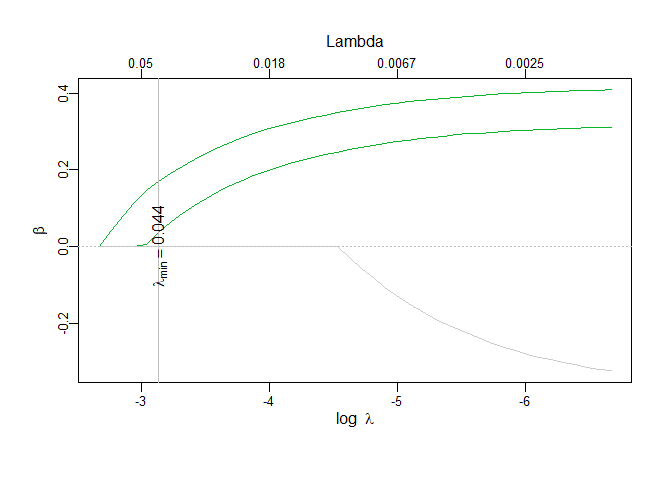

(b) Block 2 - RNA

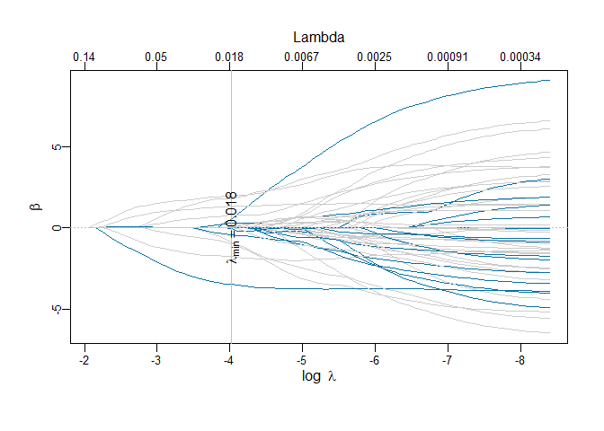

(c) Block 3 - DNA

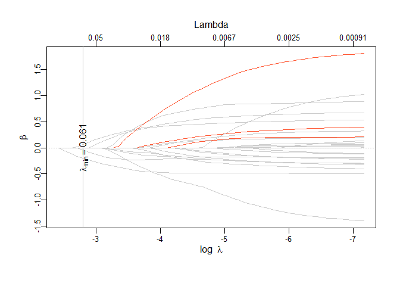

```r
cols <- c("#0AB329","#0771A2", "#FF5733")
best_fit <- cox_priority_lasso_fit$fit$best.model
for (i in seq_along(best_fit$glmnet.fit)) {

  betas <- as.vector(coef(best_fit[["glmnet.fit"]][[i]],
                          s = best_fit[["lambda.min"]][[i]]))
  beta.select <- which(betas!=0)
  cols_beta <- rep("gray80", length(betas))
  cols_beta[beta.select] <- cols[i]

  plotmo::plot_glmnet(best_fit$glmnet.fit[[i]],
                      label = FALSE, col = cols_beta,
                      xlab = expression(log ~ ~lambda),
                      ylab = expression(beta),
                      lwd = 1.5
)
  abline(v = log(best_fit[["lambda.min"]][[i]]), col = "gray")
text(log(best_fit[["lambda.min"]][[i]]), 0, bquote(paste(lambda["min"]==.(round(best_fit[["lambda.min"]][[i]], 3)))), srt = 90)
}
```

Figure 13: Coefficient values of selected variables in the Priority Lasso Cox model

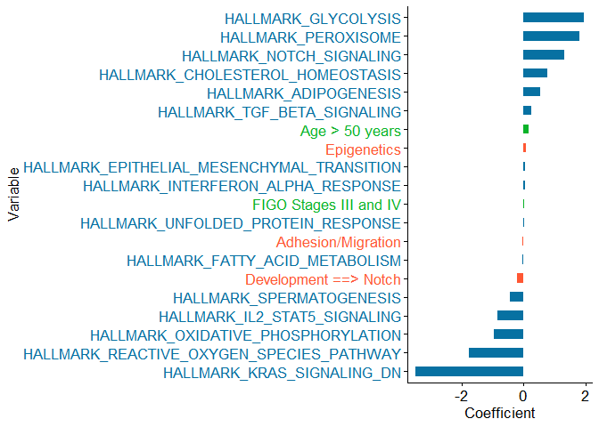

```r
plot_coef(cox_priority_lasso_fit, data_type = T)
```

On construit des modèles sans pénalisation du bloc n°1 qui correspond aux variables cliniques (`block1_penalisation = FALSE`).

```r
cox_priority_lasso_unpen_fit <- fit_cox_priority_lasso(
  time                = time,
  event               = event,
  X                   = X,
  blocks_list         = blocks_unpen_list,
  block1_penalization = FALSE,
  seed  = 123
)
```

```r
# Best block specification
cox_priority_lasso_unpen_fit$fit[["best.blocks"]]
```

```
[1] "bp1 = 1:3"   "bp2 = 30:79" "bp3 = 4:29"
```

La meilleure spécification est la suivante de blocs :

1. Clinique
2. RNA
3. DNA

Valeurs des $\lambda_{min}$ sélectionnés par validation croisée pour chacun des blocs :

```r
# Optimal lambda
cox_priority_lasso_unpen_fit$fit$best.model$lambda.min
```

```
[[1]]
NULL

[[2]]
[1] 0.01730601

[[3]]
[1] 0.0685295
```

Valeurs des erreurs de validation croisée ($min(CVE)$) pour chacun des blocs :

```r
# min CV error
cox_priority_lasso_unpen_fit$fit$best.model$min.cvm
```

```
[[1]]
NULL

[[2]]
[1] 10.44477

[[3]]
[1] 10.12283
```

Nombre de variables sélectionnées dans chacun des blocs :

```r
cox_priority_lasso_unpen_fit$fit$best.model$nzero
```

```
[[1]]
NULL

[[2]]
[1] 16

[[3]]
[1] 1
```

Figure 14: Coefficient paths for the Priority Lasso Cox model with unpenalized clinical variables

(a) Block 2 - RNA

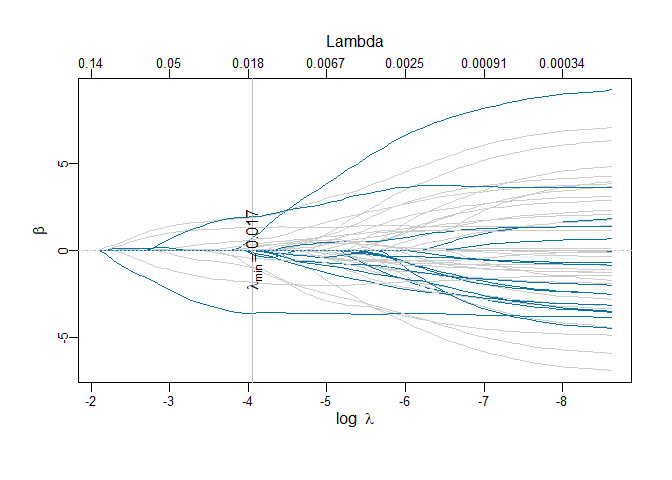

(b) Block 3 - DNA

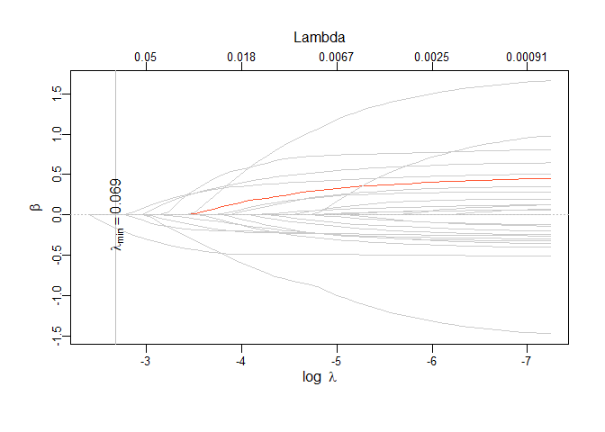

```r
cols <- c("#0AB329","#0771A2", "#FF5733")
best_fit <- cox_priority_lasso_unpen_fit$fit$best.model
for (i in 2:length(best_fit$glmnet.fit)) {

  betas <- as.vector(coef(best_fit[["glmnet.fit"]][[i]],
                          s = best_fit[["lambda.min"]][[i]]))
  beta.select <- which(betas!=0)
  cols_beta <- rep("gray80", length(betas))
  cols_beta[beta.select] <- cols[i]

  plotmo::plot_glmnet(best_fit$glmnet.fit[[i]],
                    label = FALSE, col = cols_beta,
                    xlab = expression(log ~ ~lambda),
                    ylab = expression(beta),
                    lwd = 1.5
)
  abline(v = log(best_fit[["lambda.min"]][[i]]), col = "gray")
  text(log(best_fit[["lambda.min"]][[i]]), 0, bquote(paste(lambda["min"]==.(round(best_fit[["lambda.min"]][[i]], 3)))), srt = 90)
}
```

Figure 15: Coefficient values of selected variables in the Priority Lasso Cox model with unpenalized clinical variables

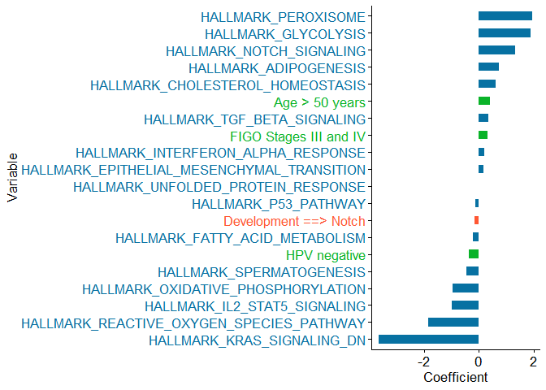

```r
plot_coef(cox_priority_lasso_unpen_fit, data_type = T)
```

# *Cox boosting*

L’algorithme de *Cox boosting* (Binder et Schumacher 2008) se présente de la façon suivante :

Soit $m = 0, \dots, m_{\text{stop}}$ l’indice des itérations de boosting, et $\hat{\beta}^{[m]}$ le vecteur des coefficients à l’itération $m$.

1. **Initialisation**
   Initialiser les coefficients à zéro :
   $$\hat{\beta}^{[0]} = 0$$
2. **Boucle de boosting**  
   Pour chaque itération $m = 0, \dots, m_{\text{stop}} - 1$ :
   1. **Calcul du gradient (score)**  
      Calculer le vecteur des dérivées premières de la log-vraisemblance partielle (score) évalué en $\hat{\beta}^{[m]}$.
   2. **Ajustement composante par composante**  
      Pour chaque variable $j$, ajuster un modèle de base (faible apprenant) en utilisant uniquement la variable $X_j$, en maximisant la log-vraisemblance partielle (ou une approximation quadratique locale).
   3. **Sélection de la meilleure variable**  
      Identifier la variable $j^*$ qui apporte la plus grande amélioration de la log-vraisemblance (ou du critère de score).
   4. **Mise à jour des coefficients**
      Mettre à jour uniquement le coefficient associé à $j^*$ :
      $$\hat{\beta}_{j^*}^{[m+1]} = \hat{\beta}_{j^*}^{[m]} + \nu \cdot \hat{\gamma}_{j^*}$$
      où $\nu \in (0,1]$ est le *shrinkage parameter* (pas d’apprentissage) et $\hat{\gamma}_{j^*}$ est l’estimation issue du modèle de base.

   Les autres coefficients restent inchangés :
   $$\hat{\beta}_{j}^{[m+1]} = \hat{\beta}_{j}^{[m]}, \quad \forall j \neq j^{*}$$
3. **Critère d’arrêt**  
   Arrêter après $m_{\text{stop}}$ itérations, ce paramètre étant généralement choisi par validation croisée.

**Important**

- Le likelihood-based boosting procède de manière **itérative et parcimonieuse**, en sélectionnant une variable à la fois.
- Le nombre d’itérations $m_{\text{stop}}$ joue un rôle de **paramètre de régularisation** (analogue au paramètre $\lambda$ du Lasso).
- Cette approche est particulièrement adaptée aux données de grande dimension et permet une **sélection automatique de variables**.
- Dans le cas du modèle de Cox, la fonction optimisée est la **log-vraisemblance partielle**.

Ajustons le modèle sur les données du TCGA en déterminant le nombre optimal d’étapes de boosting ($m_{stop}$) de façon automatique avec une validation croisée à 5 blocs. Les variables cliniques ont été incluses dans tous les modèles.

```r
cox_lboosting_fit <- fit_cox_lboost(
  time      = time,
  event     = event,
  X         = X,
  stepno    = 30,
  mandatory = clin,
  nfolds    = 5,
  seed      = 123)
```

**Note**

Dans cet exemple, nous avons limité le boosting à 30 itérations pour éviter des problèmes de convergence.

```r
summary(cox_lboosting_fit$fit)
```

```
2 boosting steps resulting in 5 non-zero coefficients (with 3 being mandatory)
partial log-likelihood: -314.9604

parameter estimates > 0:
 age, figo, hallmark_glycolysis
parameter estimates < 0:
 hpv_negative, hallmark_kras_signaling_dn
Parameter estimates for mandatory covariates:
             Estimate
age            0.4171
figo           0.3305
hpv_negative  -0.4125
```

Le nombre optimal d’itérations est de 2, conduisant à la sélection de deux variables omiques en complément des variables cliniques.

Figure 16: Coefficient paths for the CoxBoost model

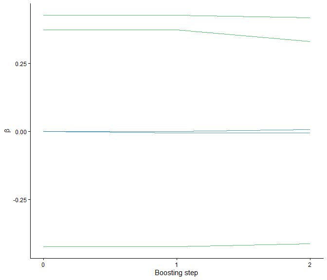

```r
plot_coef_paths(cox_lboosting_fit)
```

Les trajectoires des coefficients en fonction des étapes de boosting montrent une stabilité globale des effets estimés. Les variables cliniques obligatoires présentent des coefficients relativement constants au cours des itérations, suggérant leur contribution stable au modèle. À l’inverse, les autres variables présentent des variations limitées et restent proches de zéro, indiquant un effet faible ou nul. L’absence de divergence des coefficients confirme par ailleurs la bonne convergence du modèle dans la limite fixée du nombre d’itérations.

Nous pouvons visualiser les mises à jour des coefficients des variables sélectionnées à chaque étape de boosting :

```r
coef(cox_lboosting_fit$fit, at.step = 0) %>%
  subset(names(.) %in% cox_lboosting_fit$var_select)
```

```
                       age                       figo
                 0.4267360                  0.3722924
              hpv_negative        hallmark_glycolysis
                -0.4242385                  0.0000000
hallmark_kras_signaling_dn
                 0.0000000
```

A l’étape 0, seules les variables cliniques ont un coefficient non nul (absence de pénalisation).

```r
coef(cox_lboosting_fit$fit, at.step = 1) %>%
  subset(names(.) %in% cox_lboosting_fit$var_select)
```

```
                       age                       figo
               0.426736032                0.372292364
              hpv_negative        hallmark_glycolysis
              -0.424238491                0.000000000
hallmark_kras_signaling_dn
              -0.006279645
```

A l’étape 1, la variable `hallmark_kras_signaling_dn` est sélectionnée.

```r
coef(cox_lboosting_fit$fit, at.step = 2) %>%
  subset(names(.) %in% cox_lboosting_fit$var_select)
```

```
                       age                       figo
               0.417135588                0.330454431
              hpv_negative        hallmark_glycolysis
              -0.412512484                0.007291789
hallmark_kras_signaling_dn
              -0.006279645
```

A l’étape suivante, la variable `hallmark_glycolysis` est sélectionnée et les coefficients des variables cliniques ont été mis à jour.

Figure 17: Coefficient values of selected variables in the Cox model with likelihood-based boosting

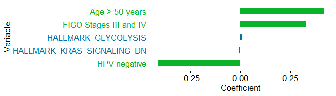

```r
plot_coef(cox_lboosting_fit, data_type = T)
```

# Importance des variables en survie

Le package `survML` comprend des fonctions permettant d’estimer l’importance des variables de manière **agnostique vis-à-vis du modèle et de l’algorithme** (cadre non paramétrique), lorsque la variable d’intérêt est un critère censuré (C. J. Wolock et al. 2024). Cette approche vise à estimer l’**importance intrinsèque des variables**, définie comme le gain prédictif au niveau de la population d’une variable ou d’un groupe de variables.

Supposons que l’on dispose d’un vecteur de variables explicatives $X$, utilisé pour prédire $T$, un temps jusqu’à événement. On note $C$ la variable de censure à droite. Les données observées sont $(X, Y, \Delta)$, où $\Delta := \mathbb{I}(T \leq C)$ et $Y := \min(T, C)$.

Pour une tâche de prédiction donnée (par exemple, estimer la probabilité que $T$ soit inférieur à un temps $\tau$) et une fonction de prédiction $f$, on note $V(f, P_0)$ la performance prédictive de $f$ sous la distribution $P_0$. On définit $f_{0,X_{-j}}$ comme la fonction de prédiction oracle excluant les variables indexées par $j$, c’est-à-dire la meilleure fonction de prédiction possible (au sens de $V$) utilisant uniquement $X_{-j}$.

Dans ce cadre, l’importance de $X_{j}$ relativement à $X_r$ est définie par :

$$\psi_j(P_0) = V(f_{0,X_{r}}, P_0) - V(f_{0,X_{-j}}, P_0)$$

Cette quantité correspond à la différence de performance prédictive maximale atteignable lorsque seules les variables de $j$ sont exclues, comparée à celle obtenue lorsque les variables de $j$ sont exclues. Elle constitue la **mesure d’importance des variables (VIM)**. $X_r$ et $X_{-j}$ correspondent respectivement aux groupes de variables « large » (avec les variables indexées par $j$) et « restreint » (après exclusion des variables indexées par $j$).

En présence de censure à droite, l’estimation des VIM nécessite l’estimation des fonctions de survie conditionnelles de $T$ et $C$ sachant $X$ :

$$S_0(t \mid x) := P_0(T > t \mid X = x), \quad
G_0(t \mid x) := P_0(C > t \mid X = x)$$

Ces fonctions doivent être estimées sur l’intervalle $(0, \tau]$ à l’aide d’un algorithme d’estimation de survie conditionnelle, tel qu’un modèle de Cox, un modèle paramétrique ou des approches plus flexibles comme le *survival Super Learner* ou le *survival stacking* (Charles J. Wolock et al. 2024).

Enfin, l’estimation requiert les fonctions de prédiction oracle $f_{0,X}$ et $f_{0,X_{-j}}$ (groupes « large » et « restreint »), dont la forme dépend de la mesure de performance choisie. Pour plusieurs mesures couramment utilisées, ces fonctions peuvent s’exprimer en fonction de $S_0(\cdot \mid x)$.

À titre d’exemple, nous considérons l’estimation de l’importance des variables omiques pour la prédiction de la survie sans progression chez les patients atteints d’un cancer du col de l’utérus, en utilisant les données du TCGA-CESC.

Dans cette analyse, un Super Learner a été utilisé pour estimer les fonctions de survie conditionnelles ainsi que les fonctions de prédiction. La bibliothèque d’apprenants a été volontairement restreinte à deux algorithmes (`SL.mean` et `SL.ranger`), utilisés avec leurs paramètres par défaut, afin de limiter le coût computationnel.

Dans ce même objectif, le paramètre `bin_size` a été fixé à 0,5. Les paramètres de nuisance ont été estimés par une procédure de cross-fitting à deux blocs, les hyperparamètres étant sélectionnés par validation croisée à deux blocs. Nous avons utilisé l’aire sous la courbe ROC cumulative/dynamique dépendante du temps, notée $AUC(t)$ (Heagerty et Zheng 2005), évaluée sur un horizon temporel prédéfini allant jusqu’à 24 mois ($t \in (0, 24]$).

Nous avons calculé les estimations ponctuelles des mesures d’importance des variables (VIM) pour toutes les variables d’intérêt ainsi que leurs intervalles de confiance (IC) à 95 %. Des p-values ont également été estimées pour l’hypothèse nulle d’importance nulle, testant si une variable contribue significativement à la prédiction au-delà du bruit aléatoire.

**Avertissement**

À noter que, pour des analyses complètes, il est recommandé d’utiliser un `bin size` plus faible, une bibliothèque d’apprenants plus riche ainsi qu’un nombre de blocs (folds) d’au moins 5. Ces choix permettent d’améliorer la précision des estimations et la robustesse des résultats.

## Estimation de l’importance des variables parmi l’ensemble des variables

Dans un premier temps, l’importance de chaque groupe de variables est évaluée relativement à l’ensemble complet des variables. Les variables d’intérêt sont exclues du vecteur complet, et leur importance est quantifiée par la diminution de la performance prédictive induite.

Autrement dit, l’importance d’une variable $X_j$ relativement à $X$ est définie par :

$$\psi_j(P)
= V\!\left(f_{X}(P),\, P\right)
- V\!\left(f_{X_{-j}}(P),\, P\right)$$
où $V\big(f_{X}(P), P\big)$ et $V\big(f_{X_{-j}}(P), P\big)$ représentent la performance prédictive optimale basée respectivement sur les fonctions de prédiction utilisant l’ensemble des covariables ($f_{X}$) et sur le vecteur complet de covariables après exclusion des variables $X_j$ ($f_{X_{-j}}$).

```r
input_full <- make_input_vimp_survML_full(
  data       = tcga_pathway,
  var_clin   = clin,
  dna_prefix = dna_pattern,
  rna_prefix = rna_pattern
)

vimp_full_fit <- compute_vimp_survML_full(
  time           = input_full$time,
  event          = input_full$event,
  X              = input_full$X,
  feature_groups = input_full$feature_groups,
  SL.library     = c("SL.mean","SL.ranger"),
  landmark_times = 24,
  type           = "AUC",
  bin_size       = 0.5,
  nfolds         = 2,
  cf_fold_num    = 2,
  seed           = 123
)
```

```r
# VIMs
vimp_full_est <- get_vimp_survML_est(vimp_full_fit)
```

Figure 18: Variable importance estimates of clinical features relative to the full feature vector

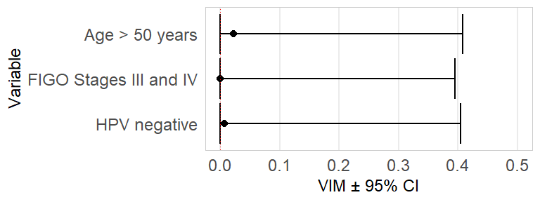

```r
vimp_full_est %>%
  dplyr::filter(variable %in% as.character(var_label(tcga_pathway[,clin])))%>%
  plot_vimp_survML_est(
    ylab   = "Variable",
    type   = "dotplot",
    limits = c(0, 0.5),
  )
```

Figure 19: Variable importance estimates of DNA pathways relative to the full feature vector

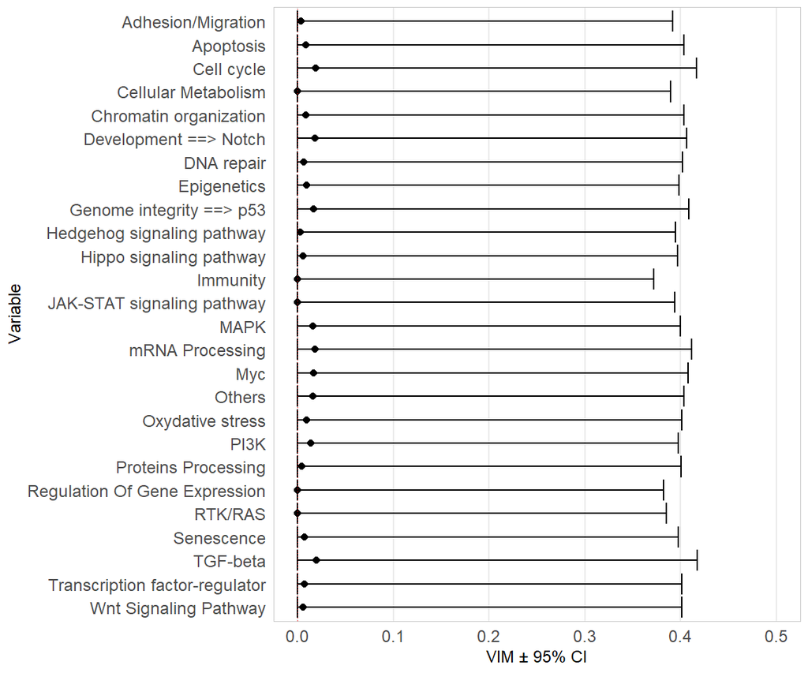

```r
vimp_full_est %>%
  dplyr::filter(data_type == "DNA_pathways")%>%
  plot_vimp_survML_est(
    ylab   = "Variable",
    type   = "dotplot",
    limits = c(0, 0.5),
  )
```

Figure 20: Variable importance estimates of RNA pathways relative to the full feature vector

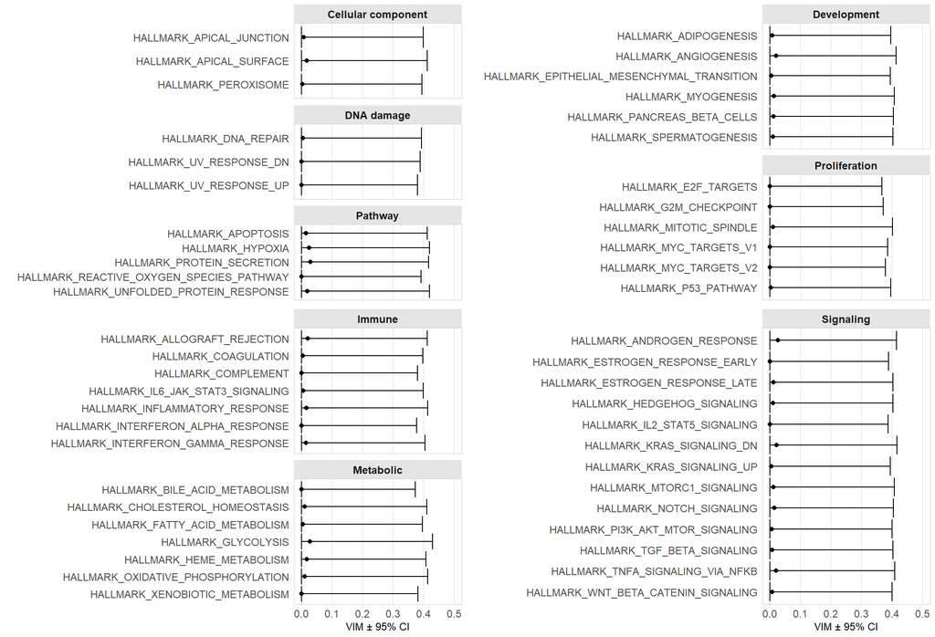

[figure not shown]

```r
vimp_full_est %>%
  dplyr::filter(data_type == "RNA_pathways")%>%
  plot_vimp_survML_est(
    ylab   = "",
    type   = "dotplot",
    limits = c(0, 0.5),
  )
```

## Estimation de l’importance des variables par rapport à un modèle de référence

Nous avons ensuite estimer l’importance des variables omiques par rapport à un modèle de référence constitué uniquement des variables cliniques.

Pour chaque pathway moléculaire ou groupe prédéfini de pathways ($X_j$), la mesure d’importance des variables a été définie relativement à un ensemble de référence de covariables cliniques ($X_{clin}$) dans un cadre non paramétrique.

Le modèle clinique de référence incluait des facteurs pronostiques établis (âge, stade FIGO et statut HPV), tandis que le modèle étendu incorporait en plus les variables d’intérêt $X_j$ (des modèles étendus distincts ont été considérés pour chaque ensemble de variables).

L’importance intrinsèque de $X_j$ est défini comme le gain de capacité prédictive associé à l’ajout de la variable $X_j$ au modèle clinique :

$$\psi_j(P)
= V\big(f_{(X_{\text{clin}}, X_j)}(P),\, P\big)
- V\big(f_{X_{\text{clin}}}(P),\, P\big)$$

où $V\big(f_{X_{\text{clin}}}(P), P\big)$ et $V\big(f_{(X_{\text{clin}}, X_j)}(P), P\big)$ représentent la performance prédictive optimale basée respectivement sur les fonctions de prédiction utilisant uniquement les covariables cliniques ($f_{X_{\text{clin}}}$) et sur l’ensemble combiné des covariables cliniques et du pathway $X_j$ ($f_{(X_{\text{clin}}, X_j)}$).

```r
input_base <- make_input_vimp_survML_base(
  data       = tcga_pathway,
  var_clin   = clin,
  dna_prefix = dna_pattern,
  rna_prefix = rna_pattern
)

vimp_base_fit <- compute_vimp_survML_base(
  time           = input_base$time,
  event          = input_base$event,
  X              = input_base$X,
  feature_groups = input_base$feature_groups,
  base_features  = input_base$base_features,
  SL.library     = c("SL.mean","SL.ranger"),
  landmark_times = 24,
  type           = "AUC",
  bin_size       = 0.5,
  nfolds         = 2,
  cf_fold_num    = 2,
  seed           = 123
)
```

```r
# VIMs
vimp_base_est <- get_vimp_survML_est(vimp_base_fit)
```

Figure 22: Variable importance estimates of DNA features relative to the base clinical model

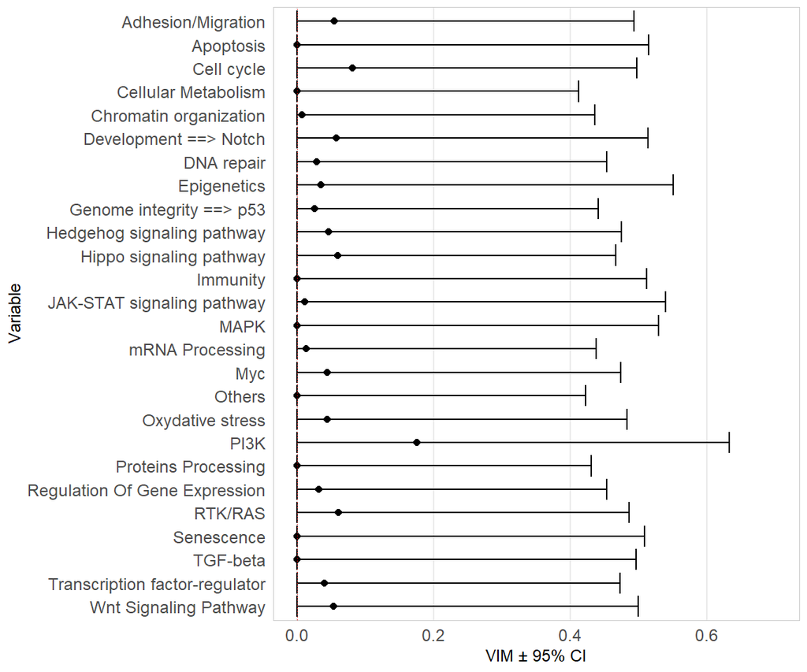

```r
vimp_base_est %>%
  dplyr::filter(data_type == "DNA_pathways")%>%
  plot_vimp_survML_est(
    ylab   = "Variable",
    type   = "dotplot",
    limits = c(0, 0.7),
  )
```

Figure 23: Variable importance estimates of RNA pathways relative to the base clinical model

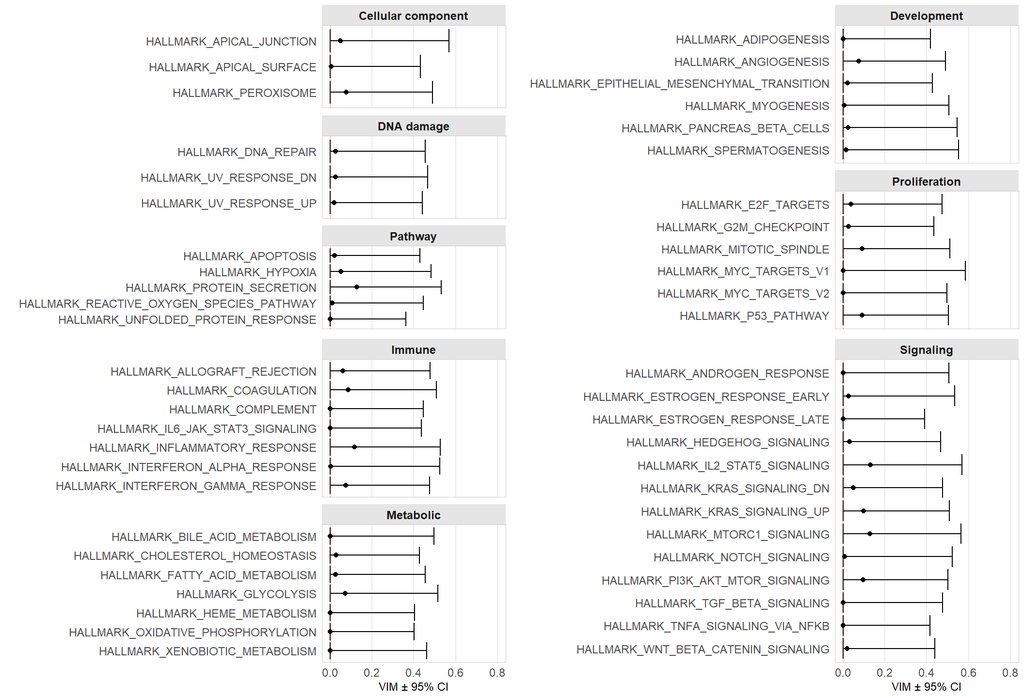

[figure not shown]

```r
vimp_base_est %>%
  dplyr::filter(data_type == "RNA_pathways")%>%
  plot_vimp_survML_est(
    ylab   = "",
    type   = "dotplot",
    limits = c(0, 0.8),
  )
```

Figure 25: Variable importance estimates of RNA processes relative to the base clinical model

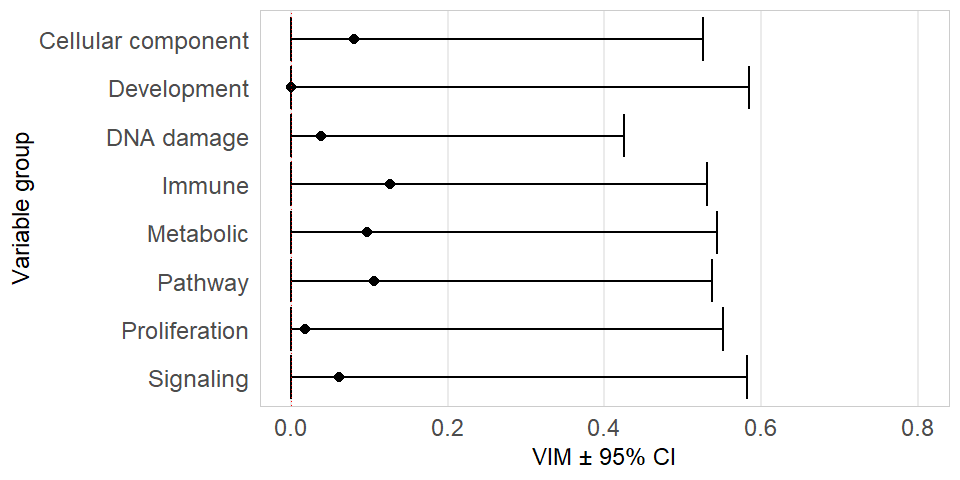

```r
vimp_base_est %>%
  dplyr::filter(data_type == "RNA_processes")%>%
  plot_vimp_survML_est(
    ylab   = "Variable group",
    type   = "dotplot",
    limits = c(0, 0.8),
  )
```

# Références

Binder, Harald, et Martin Schumacher. 2008. « Allowing for mandatory covariates in boosting estimation of sparse high-dimensional survival models ». *BMC Bioinformatics* 9 (janvier): 1‑10. https://doi.org/10.1186/1471-2105-9-14.

Breheny, Patrick, et Jian Huang. 2009. « Penalized methods for bi-level variable selection ». *Stat. Interface* 2 (3): 369‑80.

———. 2015. « Group descent algorithms for nonconvex penalized linear and logistic regression models with grouped predictors ». *Stat. Comput.* 25 (2): 173‑87.

Cheng, Jiqiu, Jonas Demeulemeester, David C Wedge, Hans Kristian M Vollan, Jason J Pitt, Hege G Russnes, Bina P Pandey, et al. 2017. « Pan-cancer analysis of homozygous deletions in primary tumours uncovers rare tumour suppressors ». *Nat. Commun.* 8 (1).

Cox, D. R. 1972. « Regression Models and Life-Tables ». *Journal of the Royal Statistical Society. Series B (Methodological)* 34 (2): 187‑220. http://www.jstor.org/stable/2985181.

Hänzelmann, Sonja, Robert Castelo, et Justin Guinney. 2013. « GSVA: gene set variation analysis for microarray and RNA-Seq data ». *BMC Bioinformatics* 14 (1): 7. https://doi.org/10.1186/1471-2105-14-7.

Heagerty, Patrick J., et Yingye Zheng. 2005. « Survival Model Predictive Accuracy and ROC Curves ». *Biometrics* 61 (1): 92‑105. https://doi.org/10.1111/j.0006-341X.2005.030814.x.

Klau, Simon, Vindi Jurinovic, Roman Hornung, Tobias Herold, et Anne-Laure Boulesteix. 2018. « Priority-Lasso: a simple hierarchical approach to the prediction of clinical outcome using multi-omics data ». *BMC Bioinformatics* 19 (1): 322.

Liberzon, Arthur, Aravind Subramanian, Reid Pinchback, Helga Thorvaldsdóttir, Pablo Tamayo, et Jill P. Mesirov. 2011. « Molecular signatures database (MSigDB) 3.0 ». *Bioinformatics* 27 (12): 1739‑40. https://doi.org/10.1093/bioinformatics/btr260.

Lucchesi, Fabiano R, et Natália D Aredes. 2016. « The Cancer Genome Atlas Cervical Squamous Cell Carcinoma and Endocervical Adenocarcinoma collection (TCGA-CESC) ». The Cancer Imaging Archive.

The Cancer Genome Atlas Research Network. 2017. « Integrated genomic and molecular characterization of cervical cancer ». *Nature* 543 (7645): 378‑84.

Tibshirani, Robert. 1997. « The Lasso Method for Variable Selection in the Cox Model ». *Statistics in Medicine* 16 (4): 385‑95. https://doi.org/10.1002/(SICI)1097-0258(19970228)16:4<385::AID-SIM380>3.0.CO;2-3.

Wolock, C J, P B Gilbert, N Simon, et M Carone. 2024. « Assessing variable importance in survival analysis using machine learning ». *Biometrika* 112 (2): asae061. https://doi.org/10.1093/biomet/asae061.

Wolock, Charles J, Peter B Gilbert, Noah Simon, et Marco Carone. 2024. « A framework for leveraging machine learning tools to estimate personalized survival curves ». *J. Comput. Graph. Stat.* 33 (3): 1098‑108.